# index

## Animal Biodiversity within NYS

## CMSC320(0201) - Final Tutorial

Jessie Lian

With the continuous advent of new technologies there exists a constant influx of data. scrutinization of said data results in valuable knowledge that is key when it comes to decision-making on a grand scale, but first, one must know how to do so.

This tutorial will guide you through the analysis of a dataset via the data science pipeline. It will cover various stages of the process such as:

- Data Collection
- Data Processing
- Exploratory Data Analysis and Visualization
- Analysis, Hypothesis Testing, Machine Learning
- Insights

## Data Collection

As with any data science project we will need a dataset to analyze.

The one we are using is from Data.gov, namely “Biodiversity by County - Distribution of Animals, Plants and Natural Communities” (https://catalog.data.gov/dataset/biodiversity-by-county-distribution-of-animals-plants-and-natural-communities). It’s a collection of various species of fauna and flora found in the state of New York and their respective conservation statuses, compiled by the NYS Department of Environmental Conservation (DEC) over the course of decades (hence why there is an entire column dedicated to the year a population was last documented).

Ecosystems are a popular point of observation, especially when the health of our environment relies on them. A crucial aspect of that is biodiversity: the variety of organisms that live in a specified area. This encompasses plants, microorganisms, animals, etc.

For this tutorial however, we will merely be focusing on animals.

You will notice two kinds of conservation statuses assigned to each species: state and global. The key thing to keep in mind is that the first letter dictates to which it is referring to, and the number indicates the status of the population itself (with 1 - Critically Imperiled, to 5 - Secure). Statuses that end in X are Presumed Extirpated or Extinct. Keep in mind that in terms of state boundaries extirpation does not equate to extinction.

You will need the following libraries:

```python
import pandas as pd
import numpy as np
import matplotlib.pyplot as plt
import seaborn as sns
import statsmodels.formula.api as sm

from sklearn.linear_model import LinearRegression
from scipy.stats import f
```

Our first step is to download the csv file from the link above, and read the dataset into a pandas DataFrame.

```python
data = pd.read_csv("Biodiversity_by_County_-_Distribution_of_Animals__Plants_and_Natural_Communities.csv")
data
```

|  | County | Category | Taxonomic Group | Taxonomic Subgroup | Scientific Name | Common Name | Year Last Documented | NY Listing Status | Federal Listing Status | State Conservation Rank | Global Conservation Rank | Distribution Status |
| --- | --- | --- | --- | --- | --- | --- | --- | --- | --- | --- | --- | --- |
| 0 | Albany | Animal | Amphibians | Frogs and Toads | Anaxyrus americanus | American Toad | 1990-1999 | Game with open season | not listed | S5 | G5 | Recently Confirmed |
| 1 | Albany | Animal | Amphibians | Frogs and Toads | Anaxyrus fowleri | Fowler's Toad | 1990-1999 | Game with open season | not listed | S4 | G5 | Recently Confirmed |
| 2 | Albany | Animal | Amphibians | Frogs and Toads | Hyla versicolor | Gray Treefrog | 1990-1999 | Game with open season | not listed | S5 | G5 | Recently Confirmed |
| 3 | Albany | Animal | Amphibians | Frogs and Toads | Lithobates catesbeianus | Bullfrog | 1990-1999 | Game with open season | not listed | S5 | G5 | Recently Confirmed |
| 4 | Albany | Animal | Amphibians | Frogs and Toads | Lithobates clamitans | Green Frog | 1990-1999 | Game with open season | not listed | S5 | G5 | Recently Confirmed |
| ... | ... | ... | ... | ... | ... | ... | ... | ... | ... | ... | ... | ... |
| 20502 | Yates | Plant | Flowering Plants | Sedges | Carex meadii | Mead's Sedge | not available | Endangered | not listed | SH | G4G5 | Historically Confirmed |
| 20503 | Yates | Plant | Flowering Plants | Sedges | Carex retroflexa | Reflexed Sedge | not available | not listed | not listed | S4 | G5 | Historically Confirmed |
| 20504 | Yates | Plant | Flowering Plants | Sedges | Carex sartwellii | Sartwell's Sedge | not available | Endangered | not listed | S1S2 | G5 | Historically Confirmed |
| 20505 | Yates | Plant | Flowering Plants | Sedges | Carex straminea | Straw Sedge | not available | Endangered | not listed | S1 | G5 | Historically Confirmed |
| 20506 | Yates | Plant | Mosses | Other Mosses | Hyophila involuta | Rolled-leaf wet ground moss | 2005 | not listed | not listed | S2S3 | G4G5 | Recently Confirmed |

20507 rows × 12 columns

## Data Processing

Now we will process the data, deciding what best suits our needs. Doing so in any data science project will expedite your analysis.

Let us drop every row belonging to a non-animal species. Afterwards we can discard this column entirely, and others that we feel will be of no use.

```python
data = data.drop(data[data['Category'] != 'Animal'].index)
data.drop(["Category", "NY Listing Status", "Federal Listing Status"], axis = 1)
```

|  | County | Taxonomic Group | Taxonomic Subgroup | Scientific Name | Common Name | Year Last Documented | State Conservation Rank | Global Conservation Rank | Distribution Status |
| --- | --- | --- | --- | --- | --- | --- | --- | --- | --- |
| 0 | Albany | Amphibians | Frogs and Toads | Anaxyrus americanus | American Toad | 1990-1999 | S5 | G5 | Recently Confirmed |
| 1 | Albany | Amphibians | Frogs and Toads | Anaxyrus fowleri | Fowler's Toad | 1990-1999 | S4 | G5 | Recently Confirmed |
| 2 | Albany | Amphibians | Frogs and Toads | Hyla versicolor | Gray Treefrog | 1990-1999 | S5 | G5 | Recently Confirmed |
| 3 | Albany | Amphibians | Frogs and Toads | Lithobates catesbeianus | Bullfrog | 1990-1999 | S5 | G5 | Recently Confirmed |
| 4 | Albany | Amphibians | Frogs and Toads | Lithobates clamitans | Green Frog | 1990-1999 | S5 | G5 | Recently Confirmed |
| ... | ... | ... | ... | ... | ... | ... | ... | ... | ... |
| 20441 | Yates | Reptiles | Snakes | Nerodia sipedon | Northern Watersnake | 1990-1999 | S5 | G5 | Recently Confirmed |
| 20442 | Yates | Reptiles | Snakes | Opheodrys vernalis | Smooth Green Snake | 1990-1999 | S4 | G5 | Recently Confirmed |
| 20443 | Yates | Reptiles | Snakes | Storeria dekayi | Dekay's Brownsnake | 1990-1999 | S5 | G5 | Recently Confirmed |
| 20444 | Yates | Reptiles | Snakes | Storeria occipitomaculata | Red-bellied Snake | 1990-1999 | S5 | G5 | Recently Confirmed |
| 20445 | Yates | Reptiles | Snakes | Thamnophis sirtalis | Common Gartersnake | 1990-1999 | S5 | G5 | Recently Confirmed |

13611 rows × 9 columns

## Exploratory Data Analysis

This part of the process is your opportunity to visualize your data in whatever way you wish, should it help you better understand it.

For one thing, why not start by looking at all of the unique state conservation ranks?

```python
s_status = data["State Conservation Rank"].unique().tolist()
s_status.sort()
print(s_status)
```

[output not shown]

As you can see there exist a wide variety of ranks; outside of those set in stone (ex. S1, S2, ... , S5) there exist populations that can only be placed in ranges, implied inexact numeric ranks, rankings for breeding and non-breeding populations, etc. A lot to keep track of, no doubt.

Let us visualize the distribution of these rankings via a bar graph, and see how healthy New York's animal ecosystem is.

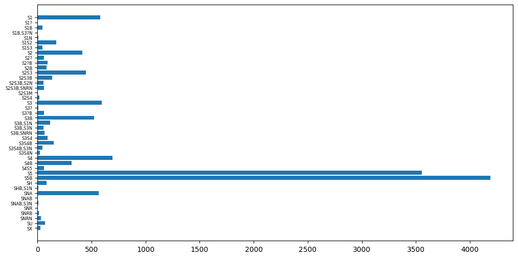

```python
state_data = data["State Conservation Rank"].unique().tolist()
state_data.sort()
count = []
for i in state_data:
    count.append(len(data[data["State Conservation Rank"] == i]))
plt.figure(figsize = (12,6))
plt.rc('xtick', labelsize = 10)
plt.rc('ytick', labelsize = 6)
plt.barh(state_data[::-1], count[::-1])
plt.show()
```

From what we can see here, the animal populations of NYS are relatively thriving! There do seem to be a handful that are critically imperiled, but compared to the amount of secure (including breeding) species one could assume this ecosystem has stable biodiversity.

Let us compare their global conservation rankings next. Remember we are now taking into account these populations as a whole, so you may already be able to predict what the next graph will look like.

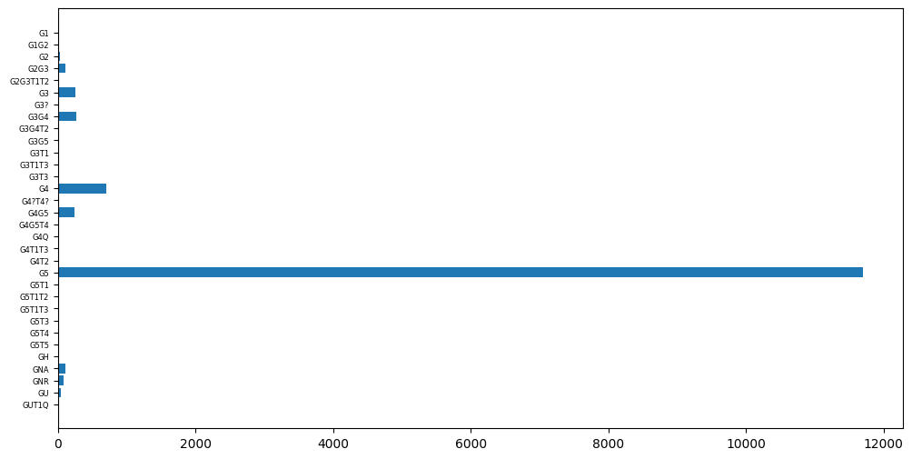

```python
global_data = data["Global Conservation Rank"].unique().tolist()
global_data.sort()
count = []
for i in global_data:
    count.append(len(data[data["Global Conservation Rank"] == i]))
plt.figure(figsize = (12,6))
plt.rc('xtick', labelsize = 10)
plt.rc('ytick', labelsize = 6)
plt.barh(global_data[::-1], count[::-1])
plt.show()
```

It appears that the majority of animal species that can be found with NYS excel globally. According to this graph populations that may be small within state boundaries itself are more likely than not, tiny portions of a whole.

This is to be expected, as it's no guarantee that the environment within the state can contain every species' ideal habitat, including food, lack of natural predators, etc.

What about state rankings relative to taxonomic groups? There could be some interesting patterns to discover there.

For simplicity's sake we will only be relying on concrete rankings. That is: S1, S2, S3, S4, S5. We will be ignoring ranges, and those that may be inexact (ending with '?'). Let's start off with a table:

```python
tax_groups = data["Taxonomic Group"].unique().tolist()

# Create a new dataframe for convenience.
srank_table = pd.DataFrame()

names = []
srank = [[], [], [], [], []]
animals = data.groupby("Taxonomic Group")

# Store data in new table.
for name, group in animals:
    names.append(name)
    srank[0].append(len(group[group["State Conservation Rank"] == "S1"]))
    srank[1].append(len(group[group["State Conservation Rank"] == "S2"]))
    srank[2].append(len(group[group["State Conservation Rank"] == "S3"]))
    srank[3].append(len(group[group["State Conservation Rank"] == "S4"]))
    srank[4].append(len(group[group["State Conservation Rank"] == "S5"]))

srank_table["Taxonomic Group"] = names
srank_cols = ["S1", "S2", "S3", "S4", "S5"]
for i in range(5):
    srank_table[srank_cols[i]] = srank[i]

srank_table
```

|  | Taxonomic Group | S1 | S2 | S3 | S4 | S5 |
| --- | --- | --- | --- | --- | --- | --- |
| 0 | Amphibians | 13 | 0 | 55 | 88 | 906 |
| 1 | Animal Assemblages | 0 | 0 | 10 | 0 | 0 |
| 2 | Bees, Wasps and Ants | 25 | 0 | 0 | 0 | 0 |
| 3 | Beetles | 3 | 3 | 0 | 0 | 0 |
| 4 | Birds | 32 | 107 | 239 | 441 | 2246 |
| 5 | Butterflies and Moths | 68 | 4 | 10 | 0 | 0 |
| 6 | Dragonflies and Damselflies | 139 | 46 | 73 | 0 | 0 |
| 7 | Fish | 75 | 133 | 0 | 0 | 0 |
| 8 | Flies | 8 | 0 | 0 | 0 | 0 |
| 9 | Mammals | 144 | 0 | 1 | 0 | 0 |
| 10 | Mayflies | 2 | 0 | 0 | 0 | 0 |
| 11 | Mussels and Clams | 40 | 81 | 0 | 0 | 0 |
| 12 | Other Animals | 10 | 31 | 142 | 25 | 62 |
| 13 | Reptiles | 17 | 8 | 66 | 138 | 343 |
| 14 | Snails | 7 | 2 | 0 | 0 | 0 |
| 15 | Stoneflies | 0 | 0 | 0 | 0 | 0 |

It seems that of the standard state conservation ranks, amphibians and birds are seeing great success in NYS, whereas those such as dragonflies and damselflies are not. But other than that, this table has revealed that more observations exist for certain species than others.

Let us quickly confirm this:

```python
sizes = animals.size()
print(sizes)
```

```
Taxonomic Group
Amphibians                     1193
Animal Assemblages               83
Bees, Wasps and Ants             34
Beetles                          20
Birds                          9678
Butterflies and Moths           264
Dragonflies and Damselflies     382
Fish                            459
Flies                            10
Mammals                         249
Mayflies                          2
Mussels and Clams               206
Other Animals                   418
Reptiles                        600
Snails                           11
Stoneflies                        2
dtype: int64
```

However (as you’ve likely noticed) this doesn’t mean birds, for example, are less threatened as a whole, merely that they are more documented. Anyone with at least some knowledge in ecology will know that arthropods make up far more of the earth’s biomass than birds do. If you recall the previous table as well, despite the fact that bugs are distributed between more taxonomic groups, there are still less species listed total than for the former. While one could assume this is due to human partiality, it’s equally as likely that more species of birds exist in NYC than do insects. But we are getting ahead of ourselves.

A great method of visualizing state ranking distributions would be through a bar graph, which would allow us to compare taxonomic groups in a different way.

We can do so with the values acquired above.

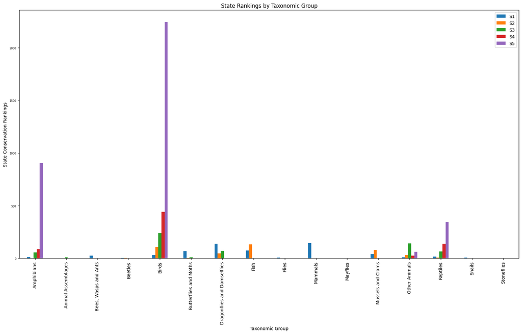

```python
srank_table.plot.bar("Taxonomic Group", ["S1", "S2", "S3", "S4", "S5"],
                     figsize = (20,10),
                     title = "State Rankings by Taxonomic Group",
                     ylabel = "State Conservation Rankings")
```

What becomes quite apparent however, is that total observations between groups vary greatly enough for it to be a distraction. It'd be more difficult to form comparisons from this.

What we could do to circumvent this issue is divide each value by the total number of documented species within that taxonomic group. That way, we compare proportions relative to each.

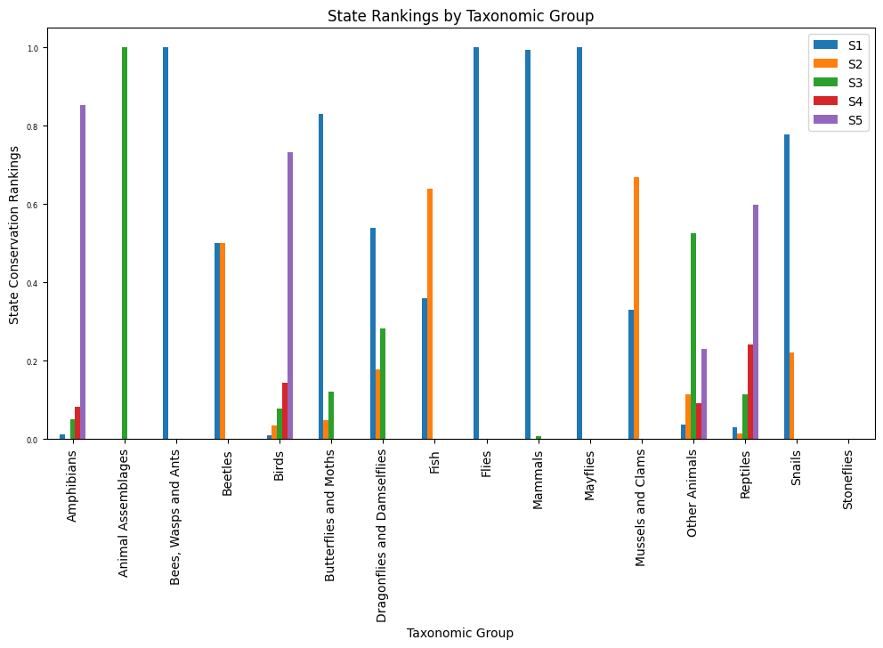

```python
# New dataframe for altered data.
new_srank = pd.DataFrame()
count = []
new_cols = [[], [], [], [], []]
for i, row in srank_table.iterrows():
    count.append(row["S1"] + row["S2"] + row["S3"] + row["S4"] + row["S5"])
    if (count[i] != 0):
        new_cols[0].append(float(row["S1"]) / count[i])
        new_cols[1].append(float(row["S2"]) / count[i])
        new_cols[2].append(float(row["S3"]) / count[i])
        new_cols[3].append(float(row["S4"]) / count[i])
        new_cols[4].append(float(row["S5"]) / count[i])
    else:
        new_cols[0].append(0.0)
        new_cols[1].append(0.0)
        new_cols[2].append(0.0)
        new_cols[3].append(0.0)
        new_cols[4].append(0.0)

for i in range(5):
    new_srank[srank_cols[i]] = new_cols[i]
new_srank["Taxonomic Group"] = srank_table["Taxonomic Group"]
new_srank["total"] = count

new_srank.plot.bar("Taxonomic Group", ["S1", "S2", "S3", "S4", "S5"],
                     figsize = (12,6),
                     title = "State Rankings by Taxonomic Group",
                     ylabel = "State Conservation Rankings")
```

This is a far less distracting arrangement already, and conveys information clearly.

In any case, these patterns still indicate that certain taxonomic groups are more threatened than others. Take mammals, for instance, where the great majority of concrete rankings are critically imperiled within NYS.

## Insights

The steps you have taken thus far should allow you to draw conclusions about your dataset.

This tutorial should not only demonstrate the data science pipeline itself but how flexible it is. Thank you for reading!